# Data Visualization Lab

STAT-4/510: Basic Consulting Skills

Braxton Adams, Cyrus Cravens, Jonathan Adiri, Sang Xing

**Complete the following lab as a group. This document should exist in your GitHub repo while you’re working on it. Your code should be heavily commented so someone reading your code can follow along easily. See the first code snippet below for an example of commented code.**

**Here’s the catch: For any given problem, the person writing the code should not be the person commenting that code, and every person must both code AND comment at least one problem in this lab (you decide how to split the work). This will involve lots of pushing and pulling through Git, and you may have to resolve conflicts if you’re not careful! Refer to last Thursday’s class notes for details on conflict resolution.**

**ALSO, all plots generated should have labeled axes, titles, and legends when appropriate. Don’t forget units of measurement! Make sure these plots could be interpreted by your client.**

# Playing with the indoor positioning system data

The `IPS_sampledata` data set contains a fraction of the indoor positioning system data for 15 randomly sampled locations.This data set is loaded into memory using the chunk of R code below, complete the following exercises.

The exercises below aim to help you polish your data visualization skills in R while simulatanelously helping you gain a better understanding of the IPS data.

First, let’s load up the data set.

```r
# loads data set IPS_sampledata
load("IPS_portion.RData")
mac_locs <- readr::read_table("accessPointLocations.txt")
```

## Variable dictionary

- `time`: timestamp in milliseconds since midnight 01/01/1970 UTC
- `scanMac`: MAC address of the scanning device (this is a handheld device)
- `posX`, `posY` and `posZ`: the (x, y, z) physical coordinate of the scanning device
- `orientation`: degree orientation of the user carrying the scanning device in degrees
- `mac`: MAC address of an access point
- `signal`: signal strength in dBm (Decibel-milliwatts)
- `channel`: the channel frequency
- `type`: type of device (access point = 3, device in adhoc mode = 1)

## Preparing the data

For this part of the lab you may use some of the code from the previous two labs to save some time.

1. Transform the variables in the data set into their correct types.

```r
IPS_sampledata %>%
  mutate(time = as.Date.POSIXct(as.numeric(time)/1000), # Transforming the time variable from char to numeric and scaling by 1000
         posX = as.numeric(posX),                       # Transforming the pos X variable from char to numeric
         posY = as.numeric(posY),                       # etc...
         posZ = as.numeric(posZ),
         orientation = as.numeric(orientation),
         signal = as.numeric(signal),
         channel = as.numeric(channel),
         type = as.numeric(type)
  ) -> IPS_sampledata                                   # Storing the new data frame into IPS_sampledata
```

2. From `IPS_sampledata`, keep only records for the six access points included in the `mac_locs` table, save these to `IPS_sampledata`.

```r
IPS_sampledata <- filter(IPS_sampledata, mac %in% mac_locs$Macs)
```

3. Create a grouped version of the `orientation` variable, with groups (bins) determined by the proximity to angles 0, 45, 90, 135, 180, 225, 270, 315.

```r
IPS_sampledata %>%
  mutate(orientation = (round(orientation / 45) * 45) %% 360) ->
  IPS_sampledata
```

4. Combine the information in `IPS_sampledata` and `mac_locs` using one of the `join_` functions we learned in class.

```r
right_join(IPS_sampledata,mac_locs,by = c("mac"= "Macs")) -> IPS_sampledata # Join by MAC address
                                                                            # right_join has the added benefit of performing part 2
```

## Getting useful visualizations

Throughout this section you’ll have some freedom to create useful visualizations for your project. [**Here is a link**](https://github.com/rstudio/cheatsheets/blob/main/data-visualization-2.1.pdf) to a `ggplot2` cheat-sheet, and [**here is another link**](https://r-graph-gallery.com/index.html) to a nice R graph gallery for inspiration.

1. Generate a scatter plot showing the locations (`posX` and `posY` in `IPS_Sampledata`) of the handheld device, as well as those from the access points (variables `x` and `y` from `mac_locs`). Use the `aesthetic` of your choosing to distinguish the handheld device locations from those corresponding to the access points.

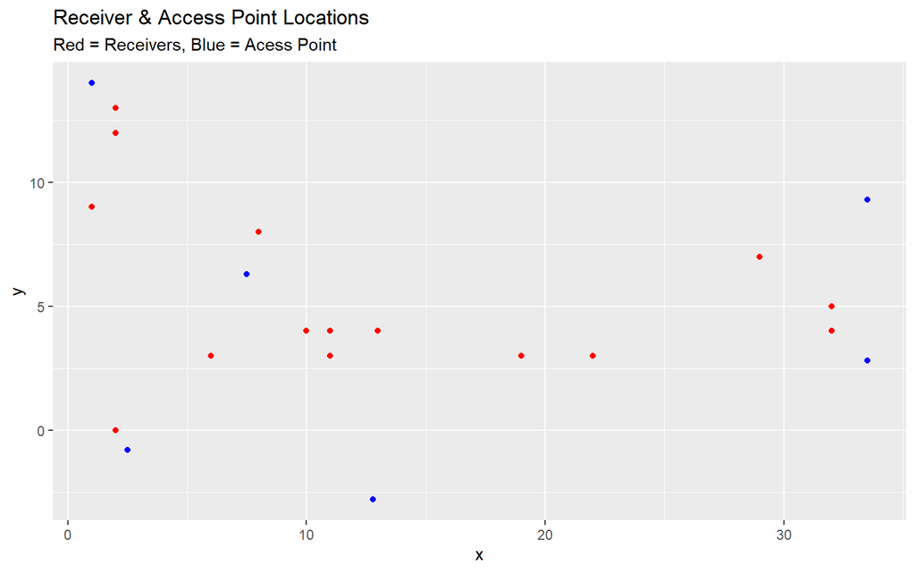

```r
IPS_sampledata %>% ggplot() +
  geom_point( aes(posX, posY), colour = "red") +  # Assign receiver coordinates a red color
  geom_point(aes(x = x, y = y ), colour="blue") + # Assign access point coordinates a blue color
  labs (                                          # Add title, subtitle, and axis labels.
    title = "Receiver & Access Point Locations",
    subtitle = "Red = Receivers, Blue = Acess Point",
    # caption = "",
    # tag = "",
    x = "x",
    y = "y",
    # colour = ""
  )
```

2. Use the resulting data set from exercise 4 from the *“Preparing the Data”* section, `group` and `summarize` it in the appropriate way to obtain the median, mean, standard deviation and any other summary statistic you consider useful to assess the signal strength for each combination of: location, orientation (the binned version), and access point.

```r
IPS_sampledata %>%
  group_by(posX,posY,posZ,orientation,mac,x,y) %>% # Group by position, orientation, and mac address. Additional "group_by" variables included so that they are not dropped by summarize.
  summarize(
    n=n(),
    mean.signal = mean(signal),     # Mean signal for each position / orientation / mac combination
    median.signal = median(signal), # Median signal "
    sd.signal = sd(signal)          # Standard Deviation of signal "
  ) %>%
  mutate(dist = sqrt((posX-x)^2+(posY-y)^2)) -> # Distance between position and access point
  IPS_summary
```

[output not shown]

3. Using the data generated from the exercise above, produce one or more visualizations (at most 3) to explore the relationship between orientation angle, location (relative to the access point), and signal strength, using `ggplot2` tools discussed in class. Briefly comment on the relationships you observe in your visualization(s) between orientation angle, distance between locations and access points, and signal strength. From your visualization(s), what cardinal direction can you relate the 0 degree orientation with?

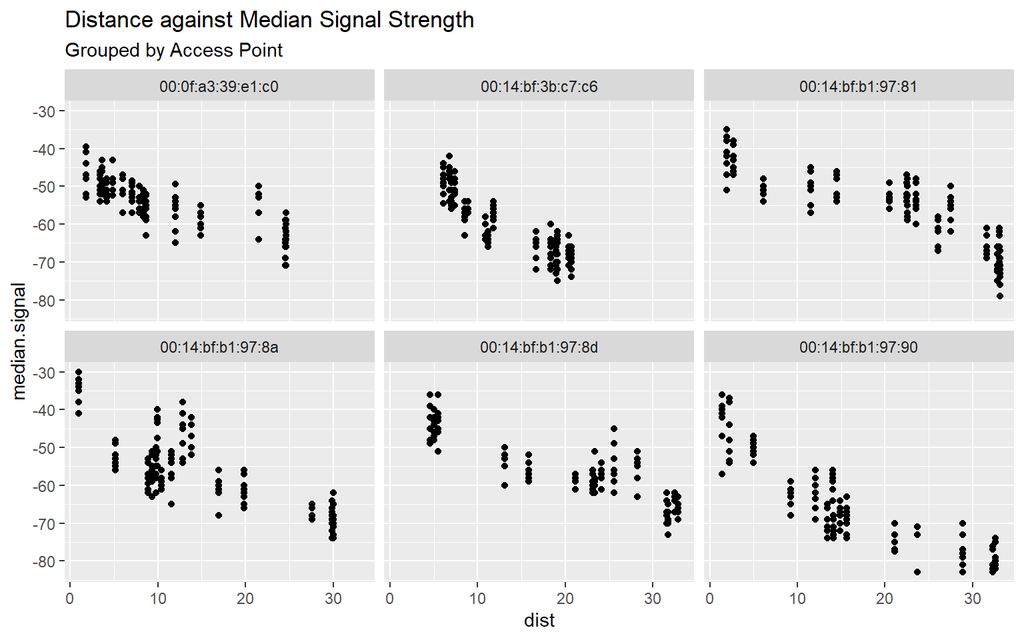

```r
IPS_summary %>%
  ggplot(aes(x = dist, y = median.signal)) +  # dis for x-axis values, median_signal for y-axis values
  geom_point() + #plot points for median signal at every orientation
  facet_wrap(~mac) + #facet with APs' mac address
  labs(
    title = "Distance against Median Signal Strength",
    subtitle = "Grouped by Access Point"
  )
```

This chart shows a general negative relationship between the distance between the reciever and access point and the recorded signal strength.

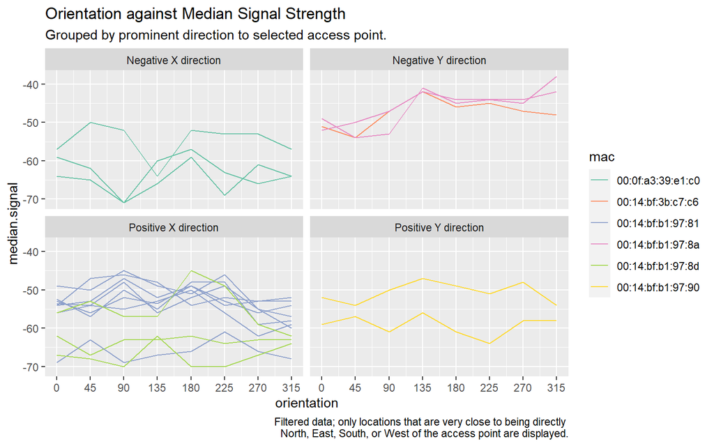

```r
IPS_summary %>%
  mutate(dx = x - posX, dy = y - posY) %>% # x-posX is the distance from recievers's x-coord to AP location
                                           # y-posy is the distance from retrievers' y-coord to AP location
  mutate(direction = case_when(
    abs(dx) > abs(dy) & dx >= 0 ~ "Positive X direction", # For any negative dx is is E of APs
    abs(dx) > abs(dy) & dx < 0  ~ "Negative X direction", # For any positive dx is is W of APs
    abs(dx) < abs(dy) & dy >= 0 ~ "Positive Y direction", # For any negative dy is is N of APs
    abs(dx) < abs(dy) & dy < 0  ~ "Negative Y direction"  # For any positive dy is is S of APs
  )) %>%
  mutate(slope = abs(dx) / abs(dy)) %>%  # Use slope to filter receivers in a boundary
  filter(slope <= 0.1 | slope >= 10) %>% # Check only the receiver within the boundary between 10 and 0.1
  #filter(orientation %% 90 == 0) %>%
  ggplot(aes(x = orientation, y = median.signal)) +
  geom_line(aes(group = paste0(posX, posY), color = mac)) +  #every line is one receiver
  scale_color_brewer(palette="Set2") +  #color receiver with its mac adress color
  facet_wrap(~direction) +  #facet with directions
  labs(
    title = "Orientation against Median Signal Strength",
    subtitle = "Grouped by prominent direction to selected access point.",
    caption = "Filtered data; only locations that are very close to being directly \nNorth, East, South, or West of the access point are displayed."
  ) +
  scale_x_continuous(breaks = seq(0, 315, by = 45)) #resale x-axis label
```

This chart appears to suggest that there may not be a clear direct relationship between orientation and signal strength. We specifically selected receiver locations that were close to being directly North, East, South, or West of an access point; for example, the point $(1,9)$ is directly West of the access point located at $(33.5, 9.3)$. The hope is that restricting the dataset to these points and plotting the signal strength against orientation would make it clear which orientation had the strongest signal strength and use that to determine the orientation that matches with North. Sadly, this seems to be inconclusive without accounting for other confounding variables.

4. Replicate the plot attached in the link.

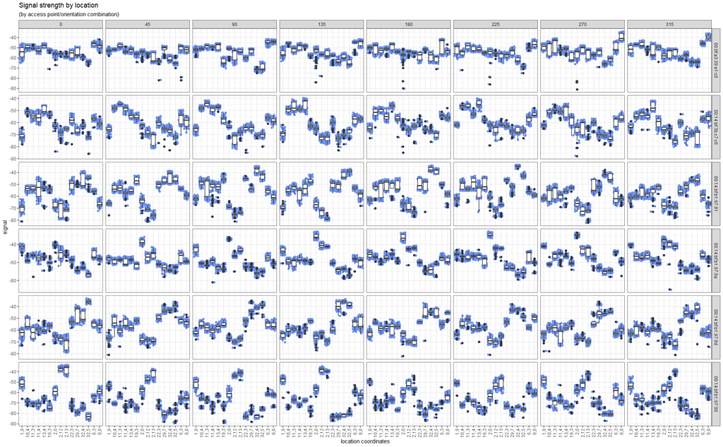

```r
# xfun::embed_file("SignalByLocation.pdf")
IPS_sampledata %>%
  mutate(posXY=paste(posX, posY, sep = ",")) %>%                # Create a new variable to uniquely identify each location.
  ggplot(aes(x = posXY, y=signal)) +                            # X axis for location, Y axis for signal strength
  geom_jitter(colour = "#6d91ed")+                              # Add each signal strength point; use geom_jitter to avoid the points overlapping.
  geom_boxplot()+                                               # Add boxplot for each position
  labs(title="Signal strength by location",
         subtitle = "(by access point/orientation combination)",
         x="location coordinates",
         y="signal")+
  facet_grid(mac~orientation, scales = "free")+                 # Facet with orientations on the "U" axis and mac addresses on the "V" axis
  theme_bw()+
  theme(axis.text.x = element_text(angle = 90, vjust = 0.5, hjust=1))  # Rotate x-xis labels
```